# Higher number of bacterial colonies and morphotypes found in the cell phones of regular college students in comparison to nursing college students

Angela Jocson

Novemeber 16, 2019

# Introduction

Cell phones have become an essential tool for modern-day life; in fact, most people tend to not leave the house unless they have their cell phone present. With cell phones becoming more a necessity rather than an accessory, it is interesting to see how much bacteria our cell phones can collect from our daily lives. In fact, in a 2014 study done by Meadow et. al, they found that about 22% of the bacterial taxa on participants’ fingers were also present on their own phones, as compared to 17% they shared on average with other people’s phones (Meadow *et al.*, 2014). Meadow et. al’s study implies that not only do cell phones hold potential as carriers to our microbiome bacteria, but also to all types of bacteria that are encountered throughout daily life.

This idea is more worrisome when considering how much bacteria our cell phones can bring in, especially when working in expectedly sterile environments such as hospitals or emergency rooms. Karabay et. al (2007) found that health professionals in a teaching hospital in Turkey carried around cell phones that did get contaminated with bacteria, such as *E. coli*, which then could have caused hospital infections (Karabay *et al.*, 2007). In this study, 111 of the 122 samples tested exhibited bacterial growth with ten (9.0%) samples indicating infectious bacteria such as *E. coli*, two *Enterococcus feacalis*, two *Pseudomonas aeruginosa*, one *Pseudomonas fluorescensis*, and one *Klebsiella pneumoniae* (2007).

Similarly, in a 2014 article done for Healthcare workers in Nigeria showed the same high percentage of bacterial contamination (94.6%) (Nwankwo *et al.*, 2014). Interestingly, they also found that the bacteria isolated from mobile phones of health care workers were more resistant to antibiotics than non-health care worker phones (2014). To confirm Nwanko et. al’s 2014 study, Taher et. al (2019) found that of their isolated bacteria species from the 93 of the studied cell phones, 80% of the bacteria were resistant to antibiotics taken from Nurse and Doctor phones (Taher, 2019). Thus, this study further emphasizes the dangerous potential for cell phones to be pathogenic bacteria carriers.

To get a better idea as to the real danger of infections caused by bacteria in phones, a study by Tajeddin et. al determined the rate of contamination of health-care workers’ hands and environmental surfaces in intensive care unit by the main bacteria associated with hospital-acquired infections in Tehran, Iran (Tajeddin *et al.*, 2016). They found that of everything tested, nurses’ aides and housekeepers were the most contaminated staff (2016). These results showed how easily contaminated trusted-sterile environments such as the ICU due to the role and neglect of health care workers when dealing with important bacterial pathogens (2016).

My main question is to see whether students working in hospitals have fewer bacterial species growing on their phones than students who work outside of the medical field and do not have to follow hospital protocols for sterility. Therefore, my hypothesis is that students who do work at hospitals with their phones on hand tend to sanitize/ sterilize their phones more, thus having significantly fewer bacteria than regular college kids who have no necessary cleaning routine for their cell phones.

In this project, I wanted to test different cell phone screens of regular college students who do not work in the health professions versus college students who are cleared to work in a hospital setting. I was particularly interested in college students due to their high-use of phones and from a study finding that there is a higher level of bacterial contamination found in secondary students’ mobile (Kõljalg *et al.*, 2017). Furthermore, I chose to test on a University campus, for similar reasons to Ross et. al in 2015, due to the high human population density and variable building usage including lecture halls, gyms, restaurants, residences, and a daycare (Ross and Neufeld, 2015). Thus, I sampled random students at the University of San Francisco but limited my study to focus on students who carry their phones everywhere (even when working in clinical sites such as Saint Mary’s Hospital. After collecting my samples, I prepared my collected swabs to be either cultured or un-cultured and analyzed them for bacterial growth based on number of colonies and different morphotypes. Further analysis involved PCR protocol, DNA sequencing and editing into phylogenetic trees, and BLASTing to identify the bacteria found in these cell phones.

### Study Question

Do students who work in hospitals/ health professions have fewer bacterial species growing on their cell phones than students who work outside of the medical field?

### Hypothesis

Students who enter hospitals with their phones tend to sanitize before and after entering hosptal rooms, thus having less bacteria than those who can use their phones freely.

### Study Design

I sampled 6 total students at the University of San Francisco, 3 Nursing students who work at the clinical site of St. Mary’s hospital (where they are supposed to clean off their phones) versus 3 students who carry their phones regularly on a daily basis. This left me with 12 samples (n = 2 swabs for each student, 12 total) to extract and sequence for bacterial DNA.

# Methods

## Sampling Plan

In order to confirm the necessary cell phone sanitizing routine when working in hospitals/ medical professional settings, I sampled this group of Nursing students directly after they come back from working at their clinical site at Saint Mary’s Hospital at 1:30 pm, Tuesday, September 3. I tried to avoid students cleaning their phones solely because of their knowledge of being tested and gained each student’s consent to swab their phones during the time and site of collection. After swabbing the health professionals, I planned on swabbing the phones of regular students who use their phones freely around the same time (2:10 pm) to avoid bacterial differences due to different samples using their phones for longer further in the day. Thus, I sampled the second group of students on Tuesday, September 3 as well on the University of San Francisco Campus.

## Sample Collection

For the collection of my samples, I had previously prepared a kit to meet the students at their easiest convenience. This kit contained 2 pairs of gloves (one for each sample group/ collection time), 6 sterile swabbing kit consisting of two swabs per pack, 6 sterile tubes with Phosphate buffer saline (pH 7.4) to preserve the swabs.

Each phone from every student (6 total) required two swabs (n = 2, 12 samples total) which were broken off and placed into the labeled test tube.

The collection sample groups were separated and assigned into two groups: group A and group B. Group A referred to the group that was current USF nursing students working at St. Mary’s Hospital and Group B were non-health related students who did not have a hospital background. Each student was given an ID label for either group A and B and a sample number was given randomly passed on collection order (1A, 2A, 3A, 1B, 2B, 3B).

After two swab samples had been taken from each student, one sample went to freeze for later DNA extraction while the other sample was set up for dilution and culture plating.

### Sample Preparation for Culturing

Once one sample had been sent away to freeze for DNA extraction, the other sample was mixed with 200 ul of PBS (7.4 pH) and vortexed for 15 seconds.

From this sample, two more tubes were prepped and labeled for a 10x dilution and 100x dilution (n = 3 per student, 18 total). For the 10x dilution, the test tube was given 180 ul of PBS plus 20 ul of the original sample and vortexed for 5 seconds. The 100x dilution was given 180 ul of PBS and 20 ul from the 10x dilution and also vortexed for 5 seconds.

I labeled and used 18 100mm Petri dish culture plates (with TSA, tryptic soy agar, as growth media) to set up bacterial culturing (n = 3 per group, 6 total). 100 ul was then taken from each sample, vortexed, and spread evenly with 8-10 Rattler beads (Spreader beads) around the bottom of the plate for about 10-20 seconds.

These culture plates were then left to incubate for 37 degrees Celcius overnight with an expected 1 culture growth per plate.

#### Culture Measurement

The following day (September 4, 2019) I measured each culture plate [for growth of colonies and monophytes.](http://https://docs.google.com/spreadsheets/d/1GTZFUkE8nhY6hZebgxoPr_dam9kGWzlqFg1O4--MyUE/edit#gid=0).

Each sample was incubated at 37 degrees Celsius and recounted 5 days after on September 9, 2019. For group A: 1A (1 colony, 1 morphotype), 2A (5 colonies, 4 morphotypes), and 3A (2 colonies, 2 morphotypes) all had the highest growth in their 100x dilution while group B: 1B (1 colony, 1 morphotype), 2B (21 colonies, 9 morphotypes), 3B all exhibited most growth at their 1x dilution (70 colonies, 4 morphotypes).

## DNA Extraction Protocol

### Culture DNA Extraction

The selected culture plates with the most colonies were given for extraction (September 10, 2019). With a 1.5 ml tube and a sterile pipette tip, cells from one colony from each plate were collected (6 total).

For DNA Extraction, I followed the Sigma Plant RED Extract-N-AMP PCR Kit (Amplicon *et al.*, 2013).

In each 1.5 ml tube, 100 ul of Extraction Solution was added and vortexed for 60 seconds. Afterward, each tube was then incubated for 10 minutes at 95 degrees Celsius and then vortexed for another 60 seconds. 100 ul of Dilution Solution was added to each tube, vortexed for 5 seconds, and centrifuged for 5 minutes at full speed.

Once each sample was done (6 total), they were then set up for Quibit protocol. I used a Qubit Fluorometric Quantification to quantitate the amount of DNA was present in each prepped tube (ng/ul). Each cultured sample was recorded for their amount of Quibit data (1A: 5.13 ng/ul, 2A: 8.09 ng/ ul, 3A: 9.75 ng/ul, 1B: 7.08 ng/ul, 2B: 7.4 ng/ul, 3B: 10.8 ng/ul).

### Culture Free DNA Extraction

The original frozen sample that was set aside during sample collection (September 3, 2019) was redistributed and prepped for DNA Extraction (September 11, 2019, 6 samples total)

This protocol also used the Sigma Plant RED Extract-N-AMP PCR Kit (Amplicon *et al.*, 2013).

Each sample was thawed and 100 ul of Extraction was added and vortexed for 60 seconds. The samples were then incubated for 10 minutes at 95 degrees Celsius and then vortexed for another 60 seconds. After, 100 ul of Dilution Solution was added and vortex for 5 seconds and centrifuged for 5 minutes.

Once finished, these samples followed the Qubit extraction (6 total). I used a Qubit Fluorometric Quantification and each cultured sample was recorded for their amount of Qubit data (1A: 6.05 ng/ul, 2A: 5.52 ng/ ul, 3A: 4.83 ng/ul, 1B: 5.91 ng/ul, 2B: 5.23 ng/ul, 3B: 4.34 ng/ul).

I recorded all data [with dilution id, concentration, and whether it was the culture or culture-free extraction.](https://docs.google.com/spreadsheets/d/19dQy8kxYwU4dCJ-AuaFwOA8AL4E97rX6VH8wT3gvDuc/edit#gid=0).

## PCR Protocol

### PCR for Culture (+ Sanger)

On September 17, 2019, I set up a PCR protocol for the cultured samples (6 total).

For my master mix, each reagent followed the equation: (n+1) + 10% (+ 1 accounting for control, and 10% accounting for any mess-ups). Including my control, I had a total of 7 samples for PCR. This resulted in calculated volumes (for n = 7 samples) of 77 ul of AMP, 6.2 ul of 27 F primer, 6.2 of 1492 R primer, 7.7 ul of BSA, 49.5 ul of H2O and 1 ul of Template DNA or 1 ul of water for the control.

17 ul of my master mix was added to each PCR tube (7 total) (although the original protocol called for 19 ul, I ended up not having enough mix.

The PCR Cycle started with the denaturing at a high temperature with PCR Conditioning starting from step one of 95 degrees C for 5 minutes, then 94 degrees C for 30 seconds, 65 degrees C for 30 seconds, and finally 72 degrees C for 1 minute. This went on for 10 cycles and each step going down 1 degree per cycle to ensure copies.

PCR followed 25 more cycles of 94 degrees C for 30 seconds, 55 degrees C for 30 seconds, 72 degrees C for 1 minute. Finally, 72 degrees C for 10 minutes, and 4 degrees C of holding.

This resulted in a total number of 35 cycles.

#### Gel Electrophoresis

Following PCR, gel electrophoresis was used running on 2 percent Agarose gel with SYBR Safe Dye added to it. 4 ul of each sample was pipetted onto the gel and ran under 140V for 30 minutes.

I photographed the final product of gel electrophoresis and noted band intensity and successful amplification.

#### Exo-SAP

On September 23, 2019, after successful amplification for gel electrophoresis, PCR products were cleaned with ExoSAP (Invitrogen) and sent for unidirectional Sanger sequencing at MCLAB (South San Francisco, CA). This was meant to digest the samples for a better Sanger Sequencing template.

### PCR of Culture Free Data (+ Illumina)

Following gel electrophoresis, PCR products were purified using AmpureXP magnetic beads (Beckman-Coulter) and quantitated using a PicoGreen fluorescent assay (Invitrogen) on a Tecan Infinite M Plex plate reader (September 23, 2019).

My master mix followed the equation (n+1) + 10% (+ 1 accounting for control, and 10% accounting for any mess-ups). In total, I had 77 ul of AMP,6.2 ul of 10 uM Iseq 165 F, 6.2 ul of 10 uM Iseq 165 R, 7.7 ul of BSA, 1 ul of the template of water for the control, and 49.5 ul of H2O (for 7 samples total, including control).

Purified PCR products were used as the template for a another round of PCR to attach the different pairs of forward and reverse Illumina barcodes (Nextera XT Index 2 kit). Other components of the PCR mixtures followed the first PCR. The PCR cycled at 95 degrees C for 3 minutes.

This went on for 25 cycles, resulting in PCR products 1,024 times smaller than the previous PCR.

#### Qubit

PCR products were purified and normalized with a SequelPrep normalization plate (Invitrogen), pooled, and quantified again using a Qubit 4 fluorometer (Invitrogen). To verify library size and concentration, TapeStation 4200 (Agilent) was used.

#### Illumina Library

This library was diluted to the loading concentration (50 pM) and combined with an Illumina PhiX spike-in library (5% spike in). It was then sequenced on an Illumina iSeq using a 2 x 150 bp consumable cartridge.

## Sequencing and Editing for Culture Data

After being sent out from the lab, my sequences were uploaded onto Geneious Prime for editing and IUPAC Coding (7 total, including water).

Here, only my samples 3a, 2b, and 3b ran all the way three and were ready to be edited. Editing involved trimming both the beginning and end of each sequence to make sure there was not too much noise. Any sequence that showed only give base pairs was regarded as a “fail” and was edited to indicate that on their Sample ID. For my sequences that ran, “allow editing” was done on Geneious Prime to look at any areas where the DNA seemed ambiguous and using my best judgment to fill in the data using [the IUPAC ambiguity code](https://droog.gs.washington.edu/parc/images/iupac.html). These edited files were labeled as “cleaned” next to their Sample ID and prepped for MAFFT Alignment.

Once I reached a high enough HQ% we used alignment to realign the working sequences with a sequence of DNA from my outgroup of *Thermus aquaticus* Strain YT-1 16 S (downloaded from the NCBI genebank), this was aligned using MAFFT (Multiple Alignment using Fast Fourier Transform) (Katoh and Standley, 2013). The realignment was trimmed at the beginning and end for each sequence to align perfectly with the outgroup.

Once aligned, I used Geneious to create a PhyML Tree and Mr. Bayes to create phylogenies comparing my DNA sequences to the outgroup. PhyML was done by taking the newly realigned sequence and running it through the PhyML program. The PhyML Tree followed a substitution model of GTR with a Branch Support of Boostrap (100 Bootstraps) (Guindon *et al.*, 2010). Any other selection were set to the default mode and the tree was created. I selected *Thermus aquaticus* as the root for my tree to act as the outgroup for my samples’ branches. Posterior probability was measured as a support value for quantifying relatedness between the branches.

To run Mr. Bayes, my realigned sequence that I ran for PhyML was selected again. Mr. Bayes parameters had a substitution model of GTR, a rate variation of invgamma, a chain length of 1,100,000, a subsampling freq of 200, and a burn-in length of 100,000 (Suchard and Redelings, 2006). Any other category was set to default. Mr. Bayes resulted in three files which showed Mr. Bayes posterior output for estimates, tree view, and trace.

The two phylogenies were uploaded using png.

BLAST was done using NCBI BLAST rather than from the Geneious program. Each freshly cleaned sequence was copied into NCBI BLAST query sequence from Geneious. For each, 16S Ribosomal RNA sequences was selected from the database and ran for results.

## Sequencing and Editing for Culture Free Data

All Illumina sequences were edited using the command-line from Terminal from my ‘my-illumina-sequences’ folder. First, sequences were counted using various script files given and unzipped as FastQC files. The sequences that returned as FastQC files were analyzed by their FastQC reports. FastQC reports provided a Quality Control report which can spot problems which originate either in the sequencer or in the starting library material. After ensuring a quality sequence from my FASTqc reports, each sequence was trimmed by Trimmomatic. Trimmomatic was run on a given script using a for-loop to edit and clean all Illumina sequences. Trimmomatic uses processing steps to trim and filter the sequences to identify adapter sequences and quality filtering (Bolger *et al.*, 2014). Again using the command-line, FastQC files were edited into fasta files for better encoding of the BLAST results. BLAST was run again using a for-loop for all Illumina sequences and all data was summarized via the cut function. All output data was stored into a separate folder.

# Results

## Qubit Data

Following protocol, I had collected Qubit data from all my samples to ensure DNA content. The Qubit fluorometer 4 (Invitrogen) uses fluorescent dyes to determine the concentration of the nucleic acids in the samples. This provided a more accurate measurement of how much DNA was successfully extracted in my samples.

| Sample Group | Sample ID | Dilution | Qubit Concentration (ng/ml) | Sample Type |
| --- | --- | --- | --- | --- |
| Nursing Student | 1a | 100 | 5.13 | Culture |
| Nursing Student | 2a | 100 | 8.09 | Culture |
| Nursing Student | 3a | 100 | 9.75 | Culture |
| Regular Student | 1b | 1 | 7.08 | Culture |
| Regular Student | 2b | 1 | 7.4 | Culture |
| Regular Student | 3b | 1 | 10.8 | Culture |
| Nursing Student | 1a | 1 | 6.05 | Culture Free |
| Nursing Student | 2a | 1 | 5.52 | Culture Free |
| Nursing Student | 3a | 1 | 4.82 | Culture Free |
| Regular Student | 1b | 1 | 5.91 | Culture Free |
| Regular Student | 2b | 1 | 5.23 | Culture Free |
| Regular Student | 3b | 1 | 4.34 | Culture Free |

**Table 1:** Table of all Qubit values for each sample. Sample types are separated between Culture data (for Sanger) and Culture Free data (for Illumina). Qubit concentration shows the nanogram of DNA is present with every ml of Qubit solution.

All samples ran with a good a good Qubit value (~3-30 ng/ml), thus indicating a good amount of DNA present in my samples to be confident in preparation for DNA sequencing.

## Gel Electrophoresis Image

### Image for Culture Data

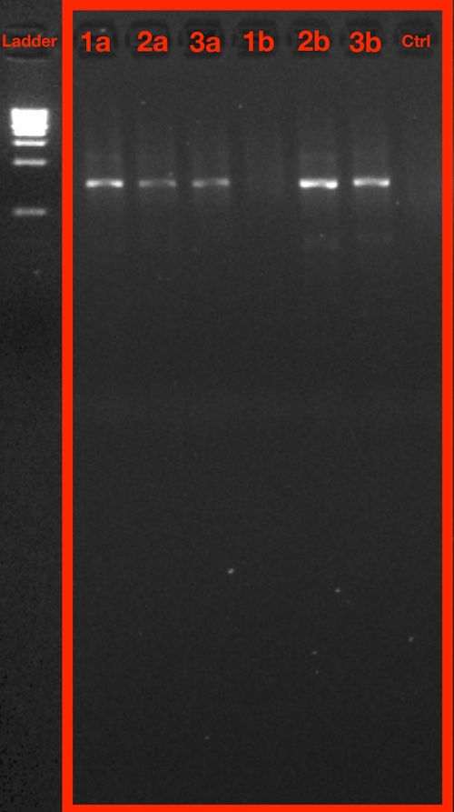

**Figure 1:** Image of Gel Electrophoresis for Culture Data. PCR bands corresponding from samples 1A, 2A, 3A, 1B, 2B, 3B, and control (left to right) are shown within the red box highlighted. A ladder is shown (furthest to the left) for comparison.

The final gel electrophoresis showcased strong bands are seen in samples 1A, 2B,and 3B. 2A and 3A were described as light bands but are still prominently shown. However, 1b and the control failed to run at all, producing no bands.

### Image for Culture Free Data

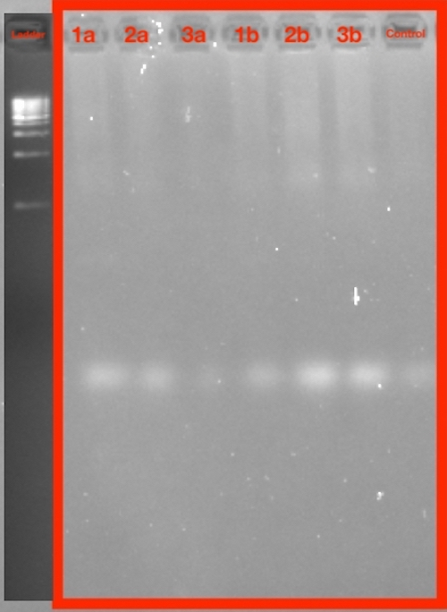

**Figure 2:** Image of Gel Electrophoresis for Culture Free Data. Each PCR bands corresponds to the samples 1A, 2A, 3A, 1B, 2B, 3B, and control (left to right) are shown within the red box highlighted. A ladder is also present (furthest to the left) for comparison.

This final gel was different in comparison to the Culture Data (Figure 1) as these bands appeared much lower within the gel. Bands for 1a, 2a, 1b, and the control all appeared very faintly in comparison to 2b and 3b which were much more distinct white bands. The sample, 3a, appeared most lightly on the gel in comparison to the other run bands.

These gel images show how the DNA within the samples were separated based on size and charge. This was also done to help indicate whether our PCR protocol would work by confirming that the samples had contained DNA which resulted in this formed bands.

## Culture Data

After ensuring that my samples had run to completion, I also wanted to quantify my culture data for any statistically significant results between my two sample groups by using my previously collected data for counting colony abundances. This data was taken after analyzing my Petri TSA plate samples, using the sample dilutions with the most amount of data.

From this collected data, I used a box plot to see the average and any outliers within my data. I also used a statistical test in order to determine how statistically significant my results were. This would allow me to make a confident conclusion as to how to interpret my data.

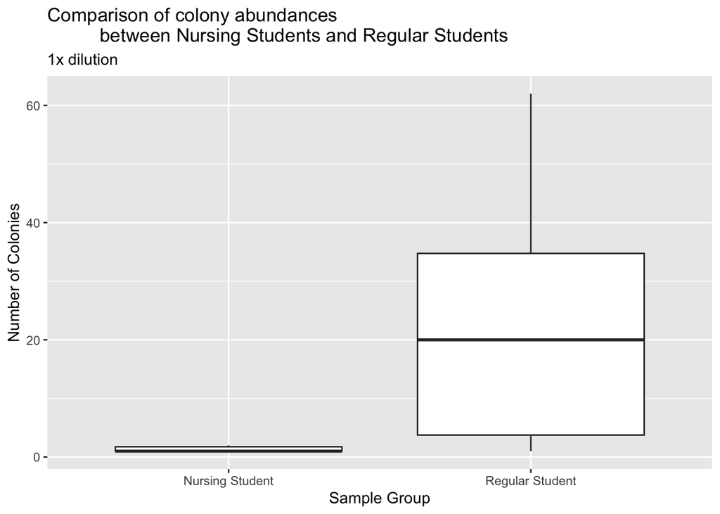

**Figure 3:** Boxplot of colony abundances at different sites, 1x dilution. The higher median number, and total number, of colonies from Regular Students versus Nursing Students was statistically significantly between the two sites (Wilcox p = 0.03650, rejec the null hypothesis).

| statistic | p.value | method | alternative |
| --- | --- | --- | --- |
| 5 | 0.0365039 | Wilcoxon rank sum test with continuity correction | two.sided |

I also wanted to look at the different types of morphotypes that appeared from each sample. Using a different variable other than colony abundances was important as colony morphotypes is a common measurement for diversity and/or isolation of the dominant species within bacterial communities (Lebaron *et al.*, 1998). Colony morphotypes can also be used to identify different species for physiological and genetic purposes (Lebaron *et al.*, 1998).

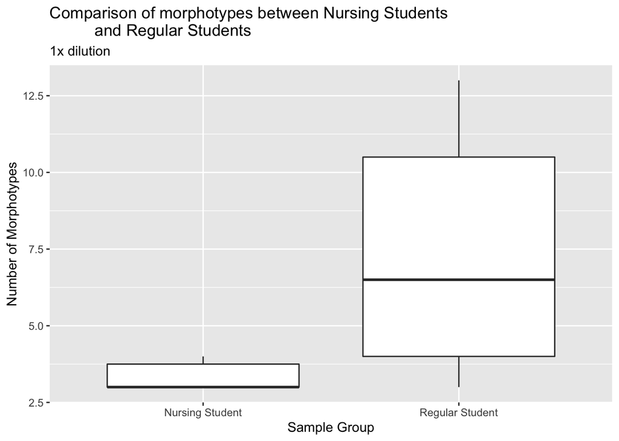

| statistic | p.value | method | alternative |
| --- | --- | --- | --- |
| 6 | 0.0516086 | Wilcoxon rank sum test with continuity correction | two.sided |

## Sequencing

As my samples werent sent to a lab and returned as sequenced DNA files, each DNA file was analyzed as whether they had failed or ran completely. Files that ran completely were cleaned and trimmed to be adjusted. I organized my data into a table in order to properly categorize and document the edits that were made to each successful sequence.

## Table for each of my sequences

[output not shown]

**Table 2:** Table showing the locus of each sequence (16S), original filename of each sequence, the filename after correcting or marking as failed, its usability (useable vs unusable), length after trimming, and number of manually corrected in the remaining sequence after trimming.

Successful sequences were 3A, 2B, and 3B. The other sequences had failed to run code (showing ’NNNN only) or had too much noise (2A). The data was then trimmed and sequenced to be ready for alignment with the outgroup *Thermus aquaticus* strain YT-1 16 S. Any ambiguity was manually corrected following [the IUPAC ambiguity code](https://droog.gs.washington.edu/parc/images/iupac.html).

## Table for each of my successful Sanger Sequences after BLAST

| Sample | Description | Percent Identity | Query Cover | Ascension | E Value |
| --- | --- | --- | --- | --- | --- |
| 1A | Sequence Failed |  |  |  |  |
| 2A | Sequence Failed |  |  |  |  |
| 3A | Moraxella Osloensis Strain PK2-16.2 | 98.65% | 99% | MN428170.1 | 0.0 |
| 1B | Sequence Failed |  |  |  |  |
| 2B | Straphylococcus warneri strain SR5-28 | 99.61% | 100% | MN421516.1 | 0.0 |
| 3B | Acinetobacter sp. strain GR14 16S | 100% | 100% | MH883927.1 | 1e-139 |

**Table 3:** Table of successful Sanger Sequences after NCBI BLAST Results. This table indiccates the BLAST result metricts which include description, percent identiy, query cover, ascension and E value.

All results from the Table were taken from NCBI Gene Bank. Each successful sequence had a high percent identity with its match found. 3A was matched with the *Moraxella osloensis* strain, 2B with the *Straphylococcus warneri* strain, and finally 3B had the *Acinetobacter* strain. Other strains had failed to sequence therefore not coming with any matches.

## Phylogenies

Following successful sequencing, my sequences were then aligned for proper phylogenetic analysis using Geneious Prime. My phylogenetic trees represent the relatedness between my sequences and the outgroup, *Thermus aquaticus*. Phylogenies allow for easier identification of the bacteria found on my samples. Two phylogenetic trees were created using different methods of construction, PhyML and Mr. Bayes.

### PhyML Phylogenetic Tree

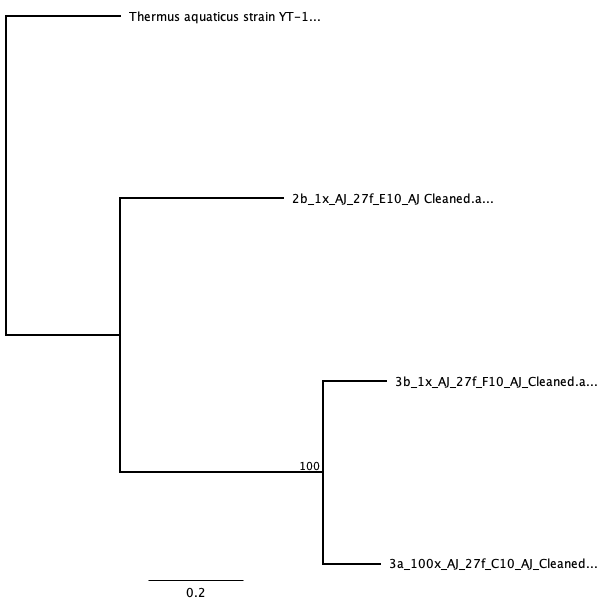

**Figure 5:** PhyML Phylogenetic tree run on Geneious Prime from Sanger Sequencing Data. Sequences that ran are 3A, 2B, and 3B with an outgroup of *Thermus aquaticus* Strain YT-1 16 S.

### Mr. Bayes Phylogenetic tree

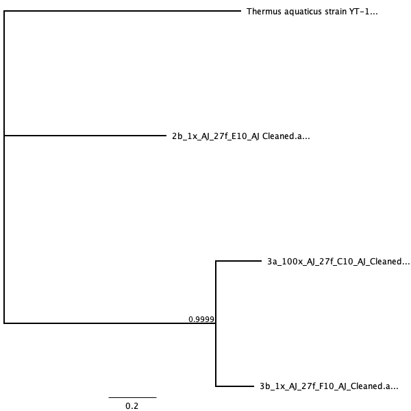

**Figure 6:** Mr. Bayes Phylogenetic tree run on Geneious Primer from Sanger Sequencing Data. Sequences that ran are 3A, 2B, and 3B with an outgroup of *Thermus aquaticus* Strain YT-1 16 S.

The PhyML Tree used the parammeters of substitution model of GTR with a value of 100 Bootstraps. Mr. Bayes ran also under GTR, a rate variation of invgamma, a chain length of 1,100,000, a subsampling freq of 200, and a burn-in length of 100,000. Phylogenetic differences between the two trees are based on the placement of 2b in relation to the related 3A and 3B and the outgroup. I found that both trees strongly associate 3A and 3B together with PhyML tree’s bootstrap value of 100 and Mr. Bayes is about 0.999 (Figure 5, 5, ML bootstrap 100 ~= Bayes 0.999). While PhyML associates 2B more closely related to 3A and 3B, Mr. Bayes places 2B alongside the outgroup.

## FastQC Report

| File Name | Sequences Flagged as Poor Quality | Sequence Length | %GC |
| --- | --- | --- | --- |
| AJ-1a_S61_L001_R1_001 | 0 | 147-151 | 52% |
| AJ-1b_S64_L001_R1_001 | 0 | 147-151 | 52% |
| AJ-2a_S62_L001_R1_001 | 0 | 41-151 | 53% |
| AJ-2b_S65_L001_R1_001 | 0 | 146-151 | 52% |
| AJ-3a_S63_L001_R1_001 | 0 | 42-151 | 53% |
| AJ-3b_S66_L001_R1_001 | 0 | 41-151 | 53% |

**Table 4:** Table of the data taken from FastQC reports. Data showcased any sequences flagged as poor quality (failure to run), sequence length, and %GC (Count(G + C)/Count(A + T + G + C) * 100%.). 1A (Nursing Student) had a sample file name of AJ-1a_S61_L001_R1_001, 1B: AJ-1b_S64_L001_R1_001 (Regular Student), 2A (Nursing Student): AJ-2a_S62_L001_R1_001, 2B: AJ-2b_S65_L001_R1_001 (Regular Student), 3A (Nursing Student): AJ-3a_S63_L001_R1_001, and 3B: AJ-3b_S66_L001_R1_001 (Regular Student).

When looking at FastQC Reports, it is important to look at the Quality Control of the file, also known as the level of quality of the Illumina Sequences ran. Each of my sequences were not flagged for poor quality and was regarded as a successful run. I lalso ooked at Sequence Length as an indicator of the length of the shortest and longest sequence within the set. AJ-1a_S61_L001_R1_001 and AJ-1b_S64_L001_R1_001 both had the same Sequence Length of 147-151 while AJ-2a_S62_L001_R1_001 and AJ-3b_S66_L001_R1_001 also had the same length of 41-151. AJ-2b_S65_L001_R1_001 and AJ-3a_S63_L001_R1_001 had sequence lengths that were one off from the first two groups respectively. I also looked at %GC which indicates the overall %GC of all bases in all sequences. This is reported as all counted G and C base pairs over total count of all possible base pairs (Count(G + C)/Count(A + T + G + C) * 100%.).Sequences AJ-1a_S61_L001_R1_001, AJ-1b_S64_L001_R1_001, and AJ-2b_S65_L001_R1_001 had a %GC of 52% while the rest of the sequences had 53%. All %GC were within the range to have all the sequences be regarded as quality sequences.

## Trimmmomatic Data

| Sample ID | Before Trimming | After Trimming | Percentage Survived |
| --- | --- | --- | --- |
| AJ-1a_S61_L001_R1_001 | 8428 | 7891 | 93.62% |
| AJ-1b_S64_L001_R1_001 | 11693 | 11129 | 95.18% |
| AJ-2a_S62_L001_R1_001 | 7788 | 7310 | 93.86% |
| AJ-2b_S65_L001_R1_001 | 15715 | 14989 | 95.38% |
| AJ-3a_S63_L001_R1_001 | 14939 | 14245 | 95.35% |
| AJ-3b_S66_L001_R1_001 | 13216 | 12393 | 93.77% |

**Table 5:** Table showcasing sequence number of each sample ran (percentage survived = after trimming /before trimming).

Trimmomatic was done from a for loop on the terminal line to trim down the sample sequences. ‘Before Trimming’ data was taken from the FastQC reports under ‘Total Sequences’ for each sample. Total sequences is a count of the total number of sequences processed. ‘After Trimming’ data was taken from the command line using the grep-c function within my illumina sequence data. Percentage survived average these two data sets. Samples AJ-1b_S64_L001_R1_001, AJ-2b_S65_L001_R1_001, AJ-3a_S63_L001_R1_001 were able to keep around 95% of the original sequences. While samples AJ-1a_S61_L001_R1_001, AJ-2a_S62_L001_R1_001, and AJ-3b_S66_L001_R1_001 kept around 93% of their original sequence. All samples maintained a high percentage survival which indicated that all sequences successfully ran.

## Command-line BLAST Analysis

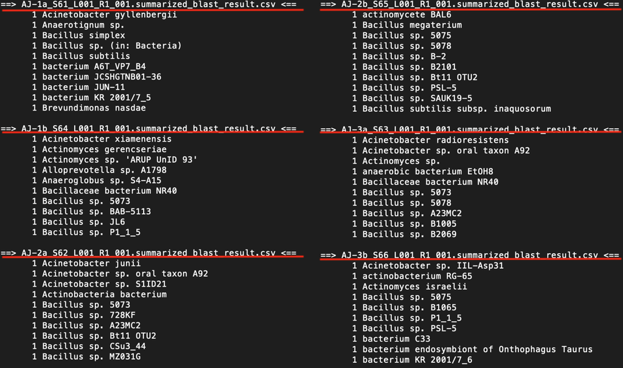

Final BLAST result for Illumina Sequences

**Figure 7:** Image showcasing final BLAST result from fasta Illumina sequence sample files on the command-line Terminal. All sequences are highlighted in red or indicated via the arrow. Each sequence had BLASTed for 10 different bacteria types with 1 of each bacteria listed below each line (n=6 sequences, 60 different bacteria listed ).

## Summary

Mobile phones have become one of the indispensable accessories in everyday modern life (Karabay *et al.*, 2007). Cell phones are taken with us everywhere even in hospital halls, laboratories, and/or intensive care units when dealing with severe illnesses (Karabay *et al.*, 2007). Moreover, college students were also noted to not only take their phones everywhere, but also are exposed to the most among germs do the density of college campuses and students (Ross and Neufeld, 2015). Thus, my study attempted to analyze whether college students who do enter hospitals (such as Nursing students) have the potential at being bacterial carriers for infections due to their cell phone use. Specifically, I had sampled the phones of 6 total college students at the University of San Francisco, 3 of which were Nursing students working at the clinical site at Saint Mary’s Hospital while the other 3 were just regular non-health related students. I had wanted to see whether Nursing students did sanitize their phones and take extra precautions in limiting their bacterial contact in comparison to regular college students. I hypothesized that Nursing students were required to clean their phones, thus showing less bacterial growth.

## Interpretation of Sanger Sequencing and Taxa

However, the difference between the two groups could easily be manipulated based on uncontrollable variances in each student’s life. For example, one student could use their phones much more carelessly by placing it on dirty surfaces, letting it stay on the floor, while another student could keep their phones in their backpacks for the day. There could also be differences in lifestyles as nursing students, like someone being on their phone during clinical site, while the other keeps it in their pocket most of the time. There was also a difference in livelihood like someone living in the dorms or a crowded house, visiting the gym more often, or even general body hygiene (such as washing hands). While I do think my data is statistically significant, it is also important to consider all possibilities when considering the two groups.

## Interpretation of Illumina Sequencing and Taxa

Each of my Culture Free samples were able to properly sequence and run through BLAST with high quality reads (Table 4, 5). Each of the samples also listed for 10 different bacterium with equivalent presence in each sample (Figure 7).

In contrast with my Culture data, 2B did not show up as the *Staphyloccus warneri* strand, but instead had a BLASTed for *actinmyocete BAL6* and other types of *Bacillus* bacterium (Figure 7). 3B did test for an *Acinetobacter sp. strain*, but this result singled out *Acinetobacter sp. IIL-Asp31*. 3A did not sequence for any *Moraxella osloensis* strain, but instead tested for *Acinetobacter*, *Actinmyces*, *Anaerobic Bacterium EtOH8*, and other *Bacillus* (Figure 7). The main difference between the newly BLASTed bacterium from my Illumina Sequences in comparison to my BLASTed Sanger Sequences is that 2B, 3B, and 3A all also had similar genera for their identified bacterium (either *Acinetobacter* and *Bacillus*). This contradicts previous studies that Nursing Students had less infectious pathogens within their cell phones, as the common genera amongst all samples were all potentially infectious.

I am much more confident in these newly resulting identified bacterium due to the fact that the Culture Free data relied on Illumina Sequencing rather than Sanger Sequencing. This is important because Sanger sequencing only allows for a single DNA fragment at a time, while Illumina Sequencing, a type of Next Generation Sequencing, can sequence millions of fragments simultaneously per run. Illumina Sequencing is considered a high-throughput process which results in a more with deep sequencing, which gives me much more confidence in the bacteria identified from my Culture Free data rather than my Cultured.

What was most interesting from Figure 7 was that all sequences for the Regular Students (1B, 2B, 3B) had tested for a type of *Actinomyces* or *actinomycete*. This was important as actinomycosis is a rare chronic disease caused by the *Actinomyces*, an anaerobic Gram-positive bacteria that normally colonize the human mouth and digestive and genital tracts (Kim *et al.*, 2014). While 3A also tested for *Actinomyces sp.*, the majority trend of Regular Students all containing the pathogen provided potential evidence that could have supported my hypothesis that Regular Students would have a greater number of harmful pathogens. However, from the other similar types of genera present in all samples, I came to the conclusion that all types of bacterium can occur on any type of phone, regardless of profession or the frequency of cell phone sanitization.

## Error Analysis

Due to the low number of actual sequencing DNA, it can be interpreted that there may have been something wrong during collection, extraction, PCR protocol, or even sequencing and everything in between (Table 2).

Key data points that may have resulted in a lack of successful sequencing could be due to experimental error. During PCR Protocol, my master mix had actually run out before the 19 ul could be delivered to each sample. Instead, I had decided to modify the procedure and use 17 ul. Thus, there could be an indication that there was not enough template for the sequence to amplify. My data also showed a lot of compression among sequences indicating DNA fragments of different sizes with the same electrophoretic mobility, ie fragments that migrate on top of each other during electrophoresis (Dillon). This phenomenon is thought to be caused by regions of secondary structure within the template DNA which could be due to PCR not having high enough temperature for denaturing. Also notable, my gel electrophoresis already indicated a failure in 1B (Figure 1), which coincides with the idea that my sequences failed to run. There were also issues with editing my sequences as a lot of them were judgment calls. This could have caused change base pairs that were manipulated to better fit one bacteria more as opposed to another. This could also have skewed the placement of my phylogenetic tree.

Other evidence of experimental failure could be due to cross-contamination, whether it be from extracting too much TSA when scraping the culture from the culture plates or by not being extra cautious when using pipette tips and handling other tools. As my Qubit data showed high numbers in the correct range, there is also the possibility that the bacteria that are found on the phones are resistant to PCR, air, water– indicating that there is a lot of versatility in bacteria that my protocol could not account for. If that is the case, PCR could be redone at high temperatures to ensure complete denaturing of the DNA strands and longer cycles for higher amplification.

Any other error in data from my Culture Free samples would be due to machine error. This can be attributed to any errors within command line (such as improper git pushes and cloning) or simple program errors from R Markdown or any other terminal commands. Other issues can be due to poor server connection when attempting to access the Tule sever within the University of San Francisco Network.

# Sources Cited

Amplicon,P. *et al.* (2013) 16s metagenomic sequencing library preparation.

Bolger,A.M. *et al.* (2014) Trimmomatic: A flexible trimmer for illumina sequence data. *Bioinformatics*, **30**, 2114–2120.

Campoccia,D. *et al.* (2010) Characterization of 26 staphylococcus warneri isolates from orthopedic infections. *The International journal of artificial organs*, **33**, 575–581.

Delarue,M. *et al.* (1990) An attempt to unify the structure of polymerases. *Protein Engineering, Design and Selection*, **3**, 461–467.

Dillon,C. Troubleshooting dna sequencing: Evaluating sanger dna sequencing chromatogram data. *Amplicon Express*.

Guindon,S. *et al.* (2010) New algorithms and methods to estimate maximum-likelihood phylogenies: Assessing the performance of phyml 3.0. *Systematic biology*, **59**, 307–321.

Karabay,O. *et al.* (2007) The role of mobile phones in the spread of bacteria associated with nosocomial infections. *J Infect Dev Ctries*, **1**, 72–3.

Katoh,K. and Standley,D.M. (2013) MAFFT multiple sequence alignment software version 7: Improvements in performance and usability. *Molecular biology and evolution*, **30**, 772–780.

Kim,Y.J. *et al.* (2014) Actinomyces-like organisms in cervical smears: The association with intrauterine device and pelvic inflammatory diseases. *Obstetrics & gynecology science*, **57**, 393–396.

Kõljalg,S. *et al.* (2017) High level bacterial contamination of secondary school students’ mobile phones. *Germs*, **7**, 73.

Kuo,S.-C. Acinetobacter species. *Acinetobacter species - Infectious Disease and Antimicrobial Agents*.

Lebaron,P. *et al.* (1998) Phenotypic and genetic diversity within a colony morphotype. *FEMS Microbiology Letters*, **160**, 137–143.

Lim,J.Y. *et al.* (2018) Complete genome sequences of three moraxella osloensis strains isolated from human skin. *Genome announcements*, **6**.

Meadow,J.F. *et al.* (2014) Mobile phones carry the personal microbiome of their owners. *PeerJ*, **2**, e447.

Nwankwo,E. *et al.* (2014) Nosocomial pathogens associated with the mobile phones of healthcare workers in a hospital in anyigba, kogi state, nigeria. *Journal of epidemiology and global health*, **4**, 135–140.

Ross,A.A. and Neufeld,J.D. (2015) Microbial biogeography of a university campus. *Microbiome*, **3**, 66.

Sadat-Ali,M. *et al.* (2010) Bacterial flora on cell phones of health care providers in a teaching institution. *American journal of infection control*, **38**, 404–405.

Sepehri,G. *et al.* (2009) Bacterial contamination and resistance to commonly used antimicrobials of healthcare workers’ mobile phones in teaching hospitals, kerman, iran. *American Journal of Applied Sciences*, **6**, 806.

Suchard,M.A. and Redelings,B.D. (2006) BAli-phy: Simultaneous bayesian inference of alignment and phylogeny. *Bioinformatics*, **22**, 2047–2048.

Taher,N.M. (2019) Pathogenic bacteria isolated from personal cell phones of health care staff in iraqi hospitals. *J Pure Appl Microbiol*, **13**, 1145–1150.

Tajeddin,E. *et al.* (2016) The role of the intensive care unit environment and health-care workers in the transmission of bacteria associated with hospital acquired infections. *Journal of infection and public health*, **9**, 13–23.

Ulger,F. *et al.* (2009) Are we aware how contaminated our mobile phones with nosocomial pathogens? *Annals of clinical microbiology and antimicrobials*, **8**, 7.

Weber,D.J. *et al.* (1988) In vitro susceptibility of bacillus spp. To selected antimicrobial agents. *Antimicrobial agents and chemotherapy*, **32**, 642–645.